# Assignment-Wage

Nihal Biswas

2023-04-22

# Importing Data

```r
setwd("C:\\Users\\nihal\\OneDrive\\Desktop\\college\\sem 2\\Economectircs")
library(readxl)
wage=read_excel("wage_dummy.xls",sheet = "Sheet1")
head(wage)
```

```
## # A tibble: 6 × 5
##      WI   AGE GENDER JOBTYPE   EDUCATION
##   <dbl> <dbl> <chr>  <chr>     <chr>
## 1   120    57 female temporary no_primary
## 2   224    48 female temporary higher
## 3   132    38 female temporary no_primary
## 4    75    27 female temporary secondary
## 5   111    23 male   permanent secondary
## 6   127    22 female temporary secondary
```

- The data set have 114 observations and 5 variables.

## Treatment of data

```r
str(wage)
```

```
## tibble [114 × 5] (S3: tbl_df/tbl/data.frame)
##  $ WI       : num [1:114] 120 224 132 75 111 127 30 24 119 75 ...
##  $ AGE      : num [1:114] 57 48 38 27 23 22 18 12 38 55 ...
##  $ GENDER   : chr [1:114] "female" "female" "female" "female" ...
##  $ JOBTYPE  : chr [1:114] "temporary" "temporary" "temporary" "temporary" ...
##  $ EDUCATION: chr [1:114] "no_primary" "higher" "no_primary" "secondary" ...
```

- The wage and age is numeric and gender, job type and education are character. So the variable types are also consistent. However, in our future study we need to change the character variables into factors.

## Missing values

```r
sum(is.na(wage))
```

```
## [1] 0
```

- There are no missing values in the data set.

# Data visualization

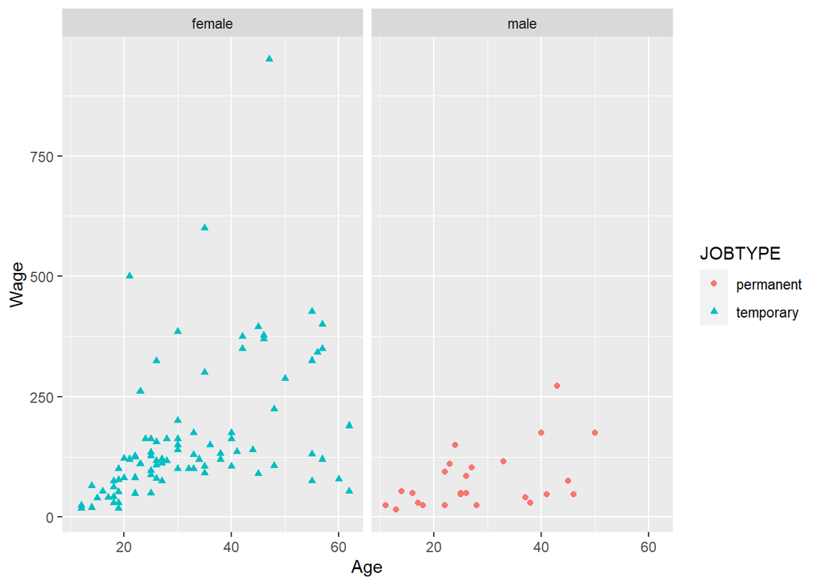

```r
library(ggplot2)
ggplot(wage,aes(AGE,WI))+geom_point(aes(color=JOBTYPE,shape=JOBTYPE))+facet_grid(~wage$GENDER)+xlab("Age")+ylab("Wage")
```

- We do see a pattern in the data that is all female are temporary employees and all male are permanent employees.

# The mean wages for different categories with respect to sex and educational level of the workers

```r
aggregate(wage$WI,by=list(wage$GENDER,wage$EDUCATION),mean)
```

```
##   Group.1    Group.2         x
## 1  female     higher 421.93333
## 2    male     higher 156.41667
## 3  female no_primary 145.13411
## 4    male no_primary  60.35222
## 5  female    primary 156.17333
## 6    male    primary  67.66000
## 7  female  secondary 202.50000
## 8    male  secondary 113.12500
```

- Over here Female with higher education has the maximum average weekly wage.
- And male with no primary education has the minimum average weekly wage.

# Linear model

### Creating Dummy variables

```r
library(fastDummies)
wage=dummy_cols(wage,select_columns = "GENDER")
wage=dummy_cols(wage,select_columns = "JOBTYPE")
wage=dummy_cols(wage,select_columns = "EDUCATION")
head(wage)
```

```
## # A tibble: 6 × 13
##      WI   AGE GENDER JOBTYPE   EDUCATION GENDE…¹ GENDE…² JOBTY…³ JOBTY…⁴ EDUCA…⁵
##   <dbl> <dbl> <chr>  <chr>     <chr>       <int>   <int>   <int>   <int>   <int>
## 1   120    57 female temporary no_prima…       1       0       0       1       0
## 2   224    48 female temporary higher          1       0       0       1       1
## 3   132    38 female temporary no_prima…       1       0       0       1       0
## 4    75    27 female temporary secondary       1       0       0       1       0
## 5   111    23 male   permanent secondary       0       1       1       0       0
## 6   127    22 female temporary secondary       1       0       0       1       0
## # … with 3 more variables: EDUCATION_no_primary <int>, EDUCATION_primary <int>,
## #   EDUCATION_secondary <int>, and abbreviated variable names ¹GENDER_female,
## #   ²GENDER_male, ³JOBTYPE_permanent, ⁴JOBTYPE_temporary, ⁵EDUCATION_higher
```

- Created dummy variables for Gender, Job Type, and Education.

### Building Model

```r
model1=lm(log(wage$WI)~wage$AGE+wage$GENDER_male+wage$EDUCATION_higher+wage$EDUCATION_secondary+wage$EDUCATION_primary+wage$JOBTYPE_permanent)
summary(model1)
```

```
##
## Call:
## lm(formula = log(wage$WI) ~ wage$AGE + wage$GENDER_male + wage$EDUCATION_higher +
##     wage$EDUCATION_secondary + wage$EDUCATION_primary + wage$JOBTYPE_permanent)
##
## Residuals:
##      Min       1Q   Median       3Q      Max
## -1.63974 -0.45654  0.04052  0.38913  1.91616
##
## Coefficients: (1 not defined because of singularities)
##                           Estimate Std. Error t value Pr(>|t|)
## (Intercept)               3.617093   0.174097  20.776  < 2e-16 ***
## wage$AGE                  0.032446   0.004653   6.974 2.58e-10 ***
## wage$GENDER_male         -0.615762   0.145968  -4.218 5.13e-05 ***
## wage$EDUCATION_higher     0.752161   0.268261   2.804  0.00599 **
## wage$EDUCATION_secondary  0.540541   0.168643   3.205  0.00177 **
## wage$EDUCATION_primary    0.158939   0.169115   0.940  0.34940
## wage$JOBTYPE_permanent          NA         NA      NA       NA
## ---
## Signif. codes:  0 '***' 0.001 '**' 0.01 '*' 0.05 '.' 0.1 ' ' 1
##
## Residual standard error: 0.6221 on 108 degrees of freedom
## Multiple R-squared:  0.4692, Adjusted R-squared:  0.4446
## F-statistic:  19.1 on 5 and 108 DF,  p-value: 1.431e-13
```

Model Inference

Inference

- Yes, Gender and Education are having differential effect on the weekly earnings.
- Female with secondary education and a particular age is earning a weekly wage of e^(3.617093+0.540541+0.032446)= Rs 66.02807 and female with higher education which same age is earning e^(3.617093+0.752161+0.032446)= Rs 81.58945. We do see a difference in weekly wage when the education level is increased.
- Person who is female at a particular age and is having a higher education is likely to earn e^(3.617093+0.752161+0.032446)= Rs 81.58945 per week. However, Male with a higher education at that same age is earning e^(3.617093-0.615762+0.752161+0.032446)= Rs 44.077. So we can see that changing the gender is also affecting the weekly wage of a person.

### Normality of the error Term

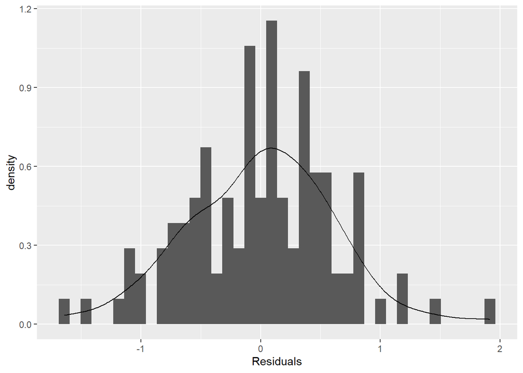

```r
library(ggplot2)
ggplot(model1,aes(model1$residuals,..density..))+geom_histogram(bins = 40)+geom_density()+xlab("Residuals")
```

- We can see from the above diagram that the Residual density curve is normally distribution.

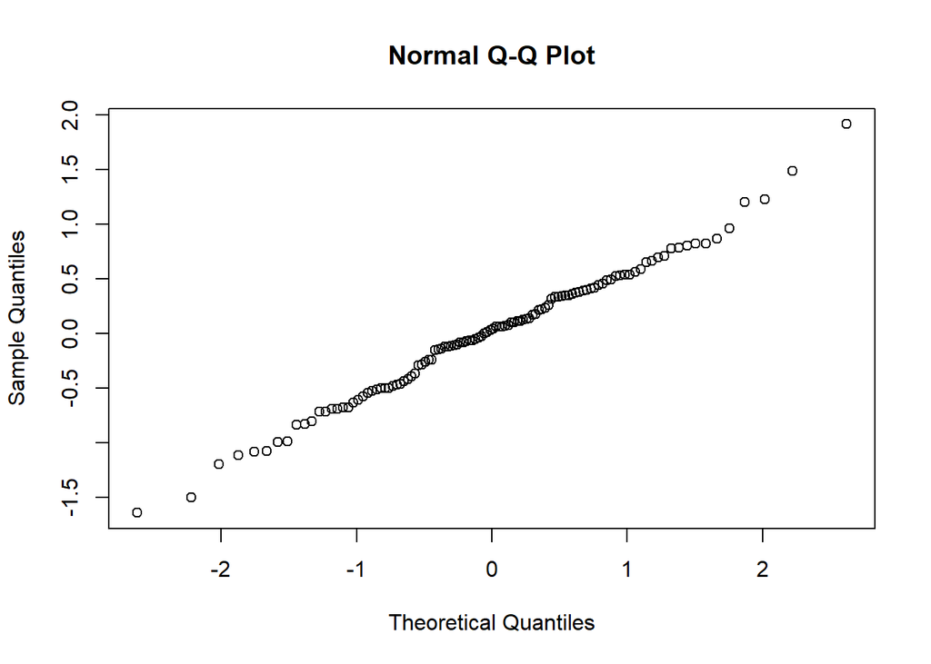

```r
qqnorm(model1$residuals)
```

- The qq-plot is also showing that the error terms are distributed normally.

# Interaction between gender and the level of education

```r
model2=lm(log(wage$WI)~wage$GENDER_male+wage$EDUCATION_higher+wage$EDUCATION_secondary+wage$EDUCATION_primary)
summary(model2)
```

```
##
## Call:
## lm(formula = log(wage$WI) ~ wage$GENDER_male + wage$EDUCATION_higher +
##     wage$EDUCATION_secondary + wage$EDUCATION_primary)
##
## Residuals:
##      Min       1Q   Median       3Q      Max
## -1.84597 -0.36075 -0.00153  0.39655  1.66058
##
## Coefficients:
##                          Estimate Std. Error t value Pr(>|t|)
## (Intercept)               4.69413    0.09633  48.732  < 2e-16 ***
## wage$GENDER_male         -0.78057    0.17267  -4.521 1.57e-05 ***
## wage$EDUCATION_higher     0.95802    0.31962   2.997  0.00337 **
## wage$EDUCATION_secondary  0.46390    0.20173   2.300  0.02338 *
## wage$EDUCATION_primary    0.04222    0.20173   0.209  0.83462
## ---
## Signif. codes:  0 '***' 0.001 '**' 0.01 '*' 0.05 '.' 0.1 ' ' 1
##
## Residual standard error: 0.7457 on 109 degrees of freedom
## Multiple R-squared:  0.2302, Adjusted R-squared:  0.202
## F-statistic:  8.15 on 4 and 109 DF,  p-value: 8.688e-06
```

Inference

- The coefficient of gender, higher education and secondary education in this model is statistically significant. Whereas, Primary education is not significant.
- Even though the new model is having a lower R-squared value, but the value of F-statistics is more that 4 which implies that the model is good fit.
- We can see from the -ve sign of the coefficient that the gender which is male in this case is having an inverse relationship with wage per week. Thus as we move from female to male there is a reduction in wage of income per week.
- Furthermore, yes there is an interaction between gender and level of education. As can been seen from the model that as the level of education goes up from secondary to higher secondary there is also and increase in the value of their respective coefficients.
- From this new model we can see that Person who is female and is having higher education is earning exp(4.69413+0.95802)= Rs 284.9034 Person who is male and is having higher education is earning exp(4.69413+0.95802-0.78057)= Rs 130.527
- And we have also seen from the above results that the average weekly wage of female with higher education is Rs 421.93333. However, for males with higher education has an average weekly wage of Rs 156.41667. So, the male workers with same level of education will earn lower weekly wages than the female.

### Normality of the error term

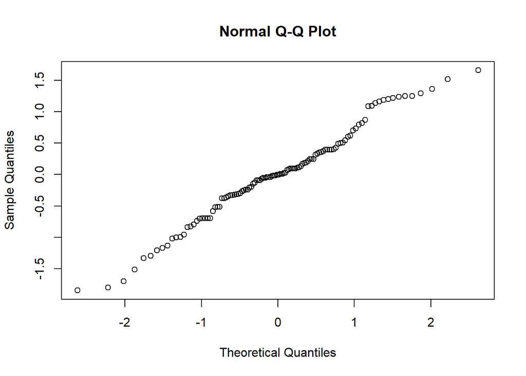

```r
qqnorm(model2$residuals)
```

- We can see from the above diagram that the points are not scattered and follows a diagonal path which signifies that the residuals are distributed normally for this model.